# Medijska zastupljenost redovničkih zajednica u hrvatskom digitalnom prostoru

Analiza ekonomije pažnje u medijskom izvještavanju o redovnicima i redovnicama

Author

DigiKat Project

Published

February 5, 2026

# Sažetak

Ovo istraživanje analizira kako hrvatski digitalni mediji prikazuju redovničke zajednice kroz teorijski okvir ekonomije pažnje. Koristeći DigiKat bazu digitalnog sadržaja od 2021. do 2025. godine, testiramo 12 hipoteza grupiranih u četiri tematske cjeline koja pokrivaju koncentraciju pažnje, spolne razlike, franjevačku dominaciju i tipologiju portala.

Ključna pitanja su dobiva li mali broj redova većinu pažnje, postoje li rodne asimetrije u izvještavanju, dominiraju li franjevci medijskim prostorom te razlikuju li se obrasci izvještavanja između mainstream i religijskih portala.

**Ključne riječi** ekonomija pažnje, redovničke zajednice, medijska reprezentacija, digitalni mediji, Hrvatska

# 1 Uvod

Ekonomija pažnje je teorijski okvir koji polazi od činjenice da je informacija obilna, ali ljudska pažnja ograničena. Svaki dan možemo pročitati samo određen broj članaka i pogledati određen broj videa. To stvara konkurenciju za istu oskudnu pažnju publike.

Za redovničke zajednice ovo stvara paradoks. S jedne strane, medijska vidljivost pomaže u privlačenju novih zvanja, donacija i javne podrške. S druge strane, traženje medijske pozornosti može biti u suprotnosti s temeljnim vrijednostima poput poniznosti i kontemplacije.

## 1.1 Teorijski okvir i hipoteze

Postavljamo 12 hipoteza grupiranih u četiri bloka.

### 1.1.1 Blok 1 Koncentracija pažnje

Teorija ekonomije pažnje predviđa neravnomjernu raspodjelu medijskog prostora.

| Hipoteza | Tvrdnja | Test |
| --- | --- | --- |
| H1a | 20% redova dobiva preko 80% prostora | Gini > 0.60, Pareto omjer |
| H1b | 10 portala proizvodi preko 50% sadržaja | CR10, HHI indeks |
| H1c | Mali broj portala piše o malom broju redova | Udio top 5×5 > 30% |

### 1.1.2 Blok 2 Spolne razlike

Istražujemo dobivaju li muške zajednice više prostora od ženskih.

| Hipoteza | Tvrdnja | Test |
| --- | --- | --- |
| H2a | Muški redovi dobivaju preko 60% prostora | Chi square test |
| H2b | Asimetrija izraženija na mainstream portalima | Test nezavisnosti |
| H2c | Objave o muškim redovima generiraju više interakcija | Mann Whitney U test |

### 1.1.3 Blok 3 Franjevačka dominacija

Franjevci imaju poseban položaj u Hrvatskoj.

| Hipoteza | Tvrdnja | Test |
| --- | --- | --- |
| H3a | Franjevačka obitelj dobiva preko 30% prostora | Binomial test |
| H3b | Udio raste u mjesecima obljetnica | T test |
| H3c | Mainstream portali fokusiraniji na franjevce | Usporedba Gini |

### 1.1.4 Blok 4 Tipologija portala

Različiti tipovi portala imaju različite uredničke logike.

| Hipoteza | Tvrdnja | Test |
| --- | --- | --- |
| H4a | Mainstream portali češće pišu o kontroverzama | Chi square test |
| H4b | Religijski portali imaju pozitivniji ton | Usporedba udjela |
| H4c | Religijski portali pišu duže članke | Mann Whitney test |

# 2 Podaci i metode

Koristimo DigiKat bazu koja sadrži objave s hrvatskih digitalnih medija prikupljene putem Determ platforme za praćenje medija. Baza pokriva razdoblje od 2021. do 2025. godine.

**Prikaži kod**

```r
franciscan_male <- list(
  ofm = list(
    name = "Franjevci (OFM)",
    family = "Franciscan Family",
    keywords = c(
      "franjevac", "franjevci", "franjevački", "franjevačka", "franjevačko",
      "fra ", "fra.", "fra\\b",
      "mala braća", "red manje braće",
      "provincija sv. ćirila i metoda", "provincija presvetog otkupitelja",
      "hrvatska franjevačka provincija", "franjevačka provincija",
      "franjevački samostan", "franjevačka crkva"
    )
  ),
  ofmconv = list(
    name = "Franjevci konventualci (OFMConv)",
    family = "Franciscan Family",
    keywords = c(
      "franjevci konventualci", "franjevac konventualac",
      "konventualci", "konventualac", "crni franjevci"
    )
  ),
  ofmcap = list(
    name = "Kapucini (OFMCap)",
    family = "Franciscan Family",
    keywords = c(
      "kapucin", "kapucini", "kapucinski",
      "kapucinska provincija", "kapucinski samostan"
    )
  ),
  tor = list(
    name = "Franjevci trećoredci (TOR)",
    family = "Franciscan Family",
    keywords = c(
      "trećoredci", "trećoredac", "trecoredci",
      "franjevci trećoredci glagoljaši"
    )
  )
)

dominican_male <- list(
  op = list(
    name = "Dominikanci (OP)",
    family = "Dominican Family",
    keywords = c(
      "dominikanac", "dominikanci", "dominikanski",
      "red propovjednika", "propovjednici",
      "dominikanski samostan", "dominikanska crkva"
    )
  )
)

jesuit <- list(
  sj = list(
    name = "Isusovci (SJ)",
    family = "Jesuit",
    keywords = c(
      "isusovac", "isusovci", "isusovački",
      "družba isusova", "societas iesu",
      "isusovačka crkva", "isusovački kolegij"
    )
  )
)

benedictine_male <- list(
  osb = list(
    name = "Benediktinci (OSB)",
    family = "Benedictine Family",
    keywords = c(
      "benediktinac", "benediktinci", "benediktinski",
      "benediktinska opatija", "benediktinski samostan"
    )
  ),
  ocist = list(
    name = "Cisterciti (OCist)",
    family = "Benedictine Family",
    keywords = c("cistercit", "cisterciti", "cistercitski")
  )
)

carmelite_male <- list(
  ocarm = list(
    name = "Karmelićani (OCarm)",
    family = "Carmelite Family",
    keywords = c(
      "karmelićanin", "karmelićani", "karmelski",
      "karmelićanski samostan"
    )
  ),
  ocd = list(
    name = "Karmelićani bosonogi (OCD)",
    family = "Carmelite Family",
    keywords = c("karmelićani bosonogi", "bosonogi karmelićani")
  )
)

salesian_male <- list(
  sdb = list(
    name = "Salezijanci (SDB)",
    family = "Salesian Family",
    keywords = c(
      "salezijanac", "salezijanci", "salezijanski",
      "don bosco", "salezijanski centar",
      "salezijanska škola", "salezijanski dom"
    )
  )
)

pauline <- list(
  osppe = list(
    name = "Pavlini (OSPPE)",
    family = "Other Male Orders",
    keywords = c("pavlin", "pavlini", "pavlinski", "red sv. pavla pustinjaka")
  )
)

missionary_male <- list(
  cssp = list(
    name = "Spiritanci (CSSp)",
    family = "Other Male Orders",
    keywords = c("spiritanac", "spiritanci", "spiritanski", "misionari duha svetoga")
  ),
  svd = list(
    name = "Verbiti (SVD)",
    family = "Other Male Orders",
    keywords = c("verbit", "verbiti", "verbitski", "družba božje riječi")
  ),
  scj = list(
    name = "Dehonijanci (SCJ)",
    family = "Other Male Orders",
    keywords = c("dehonijanac", "dehonijanci", "dehonijanski")
  ),
  smm = list(
    name = "Monfortanci (SMM)",
    family = "Other Male Orders",
    keywords = c("monfortanac", "monfortanci", "monfortanski")
  ),
  cpps = list(
    name = "Misionari Krvi Kristove (CPPS)",
    family = "Other Male Orders",
    keywords = c("misionar krvi kristove", "misionari krvi kristove")
  ),
  sac = list(
    name = "Palotinci (SAC)",
    family = "Other Male Orders",
    keywords = c("palotinac", "palotinci", "palotinski")
  )
)

other_male <- list(
  osa = list(
    name = "Augustinci (OSA)",
    family = "Other Male Orders",
    keywords = c("augustinac", "augustinci", "augustinski")
  ),
  cm = list(
    name = "Lazaristi (CM)",
    family = "Other Male Orders",
    keywords = c("lazarist", "lazaristi", "misijska družba", "vincentinci")
  ),
  cssr = list(
    name = "Redemptoristi (CSsR)",
    family = "Other Male Orders",
    keywords = c("redemptorist", "redemptoristi")
  )
)

franciscan_female <- list(
  osf_generic = list(
    name = "Franjevke (općenito)",
    family = "Franciscan Family",
    keywords = c(
      "franjevka", "franjevke", "sestre franjevke", "franjevačke sestre"
    )
  ),
  ossf = list(
    name = "Školske sestre franjevke",
    family = "Franciscan Family",
    keywords = c("školske sestre franjevke", "školska sestra franjevka")
  )
)

dominican_female <- list(
  op_f = list(
    name = "Dominikanke (OP)",
    family = "Dominican Family",
    keywords = c(
      "dominikanka", "dominikanke", "sestre dominikanke", "dominikanske sestre"
    )
  )
)

benedictine_female <- list(
  osb_f = list(
    name = "Benediktinke (OSB)",
    family = "Benedictine Family",
    keywords = c(
      "benediktinka", "benediktinke", "opatica", "benediktinski samostan"
    )
  )
)

carmelite_female <- list(
  ocd_f = list(
    name = "Karmelićanke (OCD)",
    family = "Carmelite Family",
    keywords = c(
      "karmelićanka", "karmelićanke", "sestre karmelićanke",
      "karmel", "karmelski samostan"
    )
  )
)

poor_clares <- list(
  osc = list(
    name = "Klarise (OSC)",
    family = "Franciscan Family",
    keywords = c("klarisa", "klarise", "sestre klarise", "red svete klare")
  )
)

ursulines <- list(
  osu = list(
    name = "Uršulinke (OSU)",
    family = "Congregations of Women",
    keywords = c("uršulinka", "uršulinke", "sestre uršulinke", "uršulinska škola")
  )
)

sisters_charity <- list(
  dc = list(
    name = "Milosrdnice (DC)",
    family = "Congregations of Women",
    keywords = c(
      "milosrdnica", "milosrdnice", "milosrdna sestra",
      "sestre milosrdnice", "kćeri kršćanske ljubavi"
    )
  )
)

daughters_love <- list(
  fdl = list(
    name = "Kćeri Božje Ljubavi",
    family = "Congregations of Women",
    keywords = c("kćeri božje ljubavi", "kćer božje ljubavi")
  )
)

adorers <- list(
  asc = list(
    name = "Klanjateljice Krvi Kristove",
    family = "Congregations of Women",
    keywords = c("klanjateljice krvi kristove", "klanjateljica krvi kristove")
  )
)

salesian_female <- list(
  fma = list(
    name = "Kćeri Marije Pomoćnice (FMA)",
    family = "Salesian Family",
    keywords = c(
      "kćeri marije pomoćnice", "salezijanke", "salezijanka", "sestre don bosca"
    )
  )
)

sacred_heart <- list(
  sscj = list(
    name = "Sestre Presvetog Srca Isusova",
    family = "Congregations of Women",
    keywords = c("sestre presvetog srca isusova")
  ),
  fcj = list(
    name = "Kćeri Srca Isusova",
    family = "Congregations of Women",
    keywords = c("kćeri srca isusova")
  )
)

marian_sisters <- list(
  olvm = list(
    name = "Marijine sestre čudotvorne medaljice",
    family = "Congregations of Women",
    keywords = c("marijine sestre čudotvorne medaljice")
  ),
  vhm = list(
    name = "Sestre pohoda Marijina",
    family = "Congregations of Women",
    keywords = c("sestre pohoda marijina", "vizitantke")
  )
)

servants <- list(
  sij = list(
    name = "Služavke malog Isusa",
    family = "Congregations of Women",
    keywords = c("služavke malog isusa")
  ),
  ancelle = list(
    name = "Ančele",
    family = "Congregations of Women",
    keywords = c("ančele", "ančela", "ancele")
  )
)

missionaries_charity <- list(
  mc = list(
    name = "Misionarke ljubavi",
    family = "Congregations of Women",
    keywords = c("misionarke ljubavi", "majka terezija", "sestre majke terezije")
  )
)

merciful_jesus <- list(
  smj = list(
    name = "Sestre Milosrdnog Isusa",
    family = "Congregations of Women",
    keywords = c("sestre milosrdnog isusa")
  )
)

greek_catholic <- list(
  osbm = list(
    name = "Bazilijanke (OSBM)",
    family = "Other Female Orders",
    keywords = c("bazilijanka", "bazilijanke", "vasilijanka", "vasilijanke")
  )
)

generic_terms <- list(
  male_generic = list(
    keywords = c("redovnik", "redovnici", "pater", "otac")
  ),
  female_generic = list(
    keywords = c("redovnica", "redovnice", "časna", "časna sestra", "sestra")
  ),
  institutional = list(
    keywords = c("provincija", "kustodija", "družba", "samostan", "opatija",
                 "provincijalat", "generalni poglavar", "provincijal")
  )
)
```

**Prikaži kod**

```r
extract_keywords <- function(order_list) {
  keywords <- c()
  for (order in order_list) {
    if (!is.null(order$keywords)) {
      keywords <- c(keywords, order$keywords)
    }
  }
  return(keywords)
}

male_order_keywords <- c(
  extract_keywords(franciscan_male),
  extract_keywords(dominican_male),
  extract_keywords(jesuit),
  extract_keywords(benedictine_male),
  extract_keywords(carmelite_male),
  extract_keywords(salesian_male),
  extract_keywords(pauline),
  extract_keywords(missionary_male),
  extract_keywords(other_male)
)

female_order_keywords <- c(
  extract_keywords(franciscan_female),
  extract_keywords(dominican_female),
  extract_keywords(benedictine_female),
  extract_keywords(carmelite_female),
  extract_keywords(poor_clares),
  extract_keywords(ursulines),
  extract_keywords(sisters_charity),
  extract_keywords(daughters_love),
  extract_keywords(adorers),
  extract_keywords(salesian_female),
  extract_keywords(sacred_heart),
  extract_keywords(marian_sisters),
  extract_keywords(servants),
  extract_keywords(missionaries_charity),
  extract_keywords(merciful_jesus),
  extract_keywords(greek_catholic)
)

generic_keywords <- c(
  generic_terms$male_generic$keywords,
  generic_terms$female_generic$keywords,
  generic_terms$institutional$keywords
)

all_order_keywords <- unique(c(
  male_order_keywords,
  female_order_keywords,
  generic_keywords
))

all_order_keywords_clean <- gsub("\\\\b", "", all_order_keywords)
simple_keywords <- tolower(all_order_keywords_clean)
simple_keywords <- simple_keywords[nchar(simple_keywords) > 2]
```

**Prikaži kod**

```r
classify_portal_type <- function(source_name) {
  source_lower <- tolower(source_name)

  mainstream_national <- c(
    "index.hr", "vecernji.hr", "jutarnji.hr", "24sata.hr", "net.hr",
    "telegram.hr", "nacional.hr", "slobodnadalmacija.hr", "novilist.hr",
    "dnevnik.hr", "rtl.hr", "n1info.hr"
  )

  religious_catholic <- c(
    "ika.hr", "bitno.net", "katolicki.hr", "laudato.hr", "veritas.hr",
    "catholic.hr", "crkva.hr", "nadbiskupija", "biskupija", "zupa",
    "katolicki-tjednik", "svetoduh"
  )

  if (any(sapply(mainstream_national, function(x) grepl(x, source_lower, fixed = TRUE)))) {
    return("Mainstream National")
  }

  if (any(sapply(religious_catholic, function(x) grepl(x, source_lower, fixed = TRUE)))) {
    return("Religious Catholic")
  }

  return("Local/Regional")
}
```

**Prikaži kod**

```r
dta_full <- readRDS("C:/Users/lsikic/Luka C/HKS/Projekti/Digitalni Kat/SHKM/DigiKat/data/merged_comprehensive.rds")

setDT(dta_full)

if (is.character(dta_full$DATE)) {
  dta_full[, DATE := as.Date(DATE)]
}

## FIX: ensure year and month columns exist derived from DATE
if (!"year" %in% names(dta_full)) {
  dta_full[, year := year(DATE)]
}
if (!"month" %in% names(dta_full)) {
  dta_full[, month := month(DATE)]
}

dta_full <- dta_full[SOURCE_TYPE == "web"]
dta_full <- dta_full[DATE >= as.Date("2021-01-01") & DATE <= as.Date("2025-12-31")]
dta_full <- dta_full[year >= 2021 & year <= 2025]

cat("Učitana DigiKat baza podataka\n")
```

```
Učitana DigiKat baza podataka
```

**Prikaži kod**

```r
cat("Ukupno objava", format(nrow(dta_full), big.mark = ","), "\n")
```

```
Ukupno objava 447,908
```

**Prikaži kod**

```r
dta_full[, text_lower := tolower(paste(
  ifelse(is.na(TITLE), "", TITLE),
  ifelse(is.na(FULL_TEXT), "", FULL_TEXT),
  ifelse(is.na(MENTION_SNIPPET), "", MENTION_SNIPPET)
))]

cat("Filtriranje sadržaja o redovničkim zajednicama\n")
```

```
Filtriranje sadržaja o redovničkim zajednicama
```

**Prikaži kod**

```r
dta_full[, has_order_content := FALSE]

chunk_size <- 50000
n_chunks <- ceiling(nrow(dta_full) / chunk_size)

for (i in 1:n_chunks) {
  start_idx <- (i - 1) * chunk_size + 1
  end_idx <- min(i * chunk_size, nrow(dta_full))

  dta_full[start_idx:end_idx, has_order_content := sapply(
    text_lower,
    function(t) any(sapply(simple_keywords, function(k) grepl(k, t, fixed = TRUE)))
  )]

  if (i %% 10 == 0) cat("Obrađen blok", i, "od", n_chunks, "\n")
}

dta <- dta_full[has_order_content == TRUE]

if (is.character(dta$DATE)) {
  dta[, DATE := as.Date(DATE)]
}

## FIX: ensure year and month exist on the filtered subset too
if (!"year" %in% names(dta)) {
  dta[, year := year(DATE)]
}
if (!"month" %in% names(dta)) {
  dta[, month := month(DATE)]
}

dta_full[, text_lower := NULL]
dta_full[, has_order_content := NULL]

cat("\nFiltriranje završeno\n")
```

```
Filtriranje završeno
```

**Prikaži kod**

```r
cat("Objave o redovničkim zajednicama", format(nrow(dta), big.mark = ","), "\n")
```

```
Objave o redovničkim zajednicama 231,503
```

**Prikaži kod**

```r
cat("Postotak ukupnog korpusa", sprintf("%.2f%%", nrow(dta) / nrow(dta_full) * 100), "\n")
```

```
Postotak ukupnog korpusa 51.69%
```

**Prikaži kod**

```r
classify_religious_order <- function(text) {
  if (is.na(text) || text == "") return(list(order = "Unknown", family = "Unknown", gender = "Unknown"))

  text_lower <- tolower(text)

  if (any(sapply(c("franjevac", "franjevci", "\\bfra\\b", "fra ", "mala braća"),
                 function(k) grepl(k, text_lower)))) {
    if (grepl("konventual", text_lower)) {
      return(list(order = "Franjevci konventualci", family = "Franciscan Family", gender = "Male"))
    }
    if (!grepl("franjevk", text_lower)) {
      return(list(order = "Franjevci OFM", family = "Franciscan Family", gender = "Male"))
    }
  }

  if (grepl("kapucin", text_lower)) {
    return(list(order = "Kapucini", family = "Franciscan Family", gender = "Male"))
  }

  if (grepl("dominikanac|dominikanci", text_lower) && !grepl("dominikank", text_lower)) {
    return(list(order = "Dominikanci", family = "Dominican Family", gender = "Male"))
  }

  if (grepl("isusovac|isusovci|družba isusova", text_lower)) {
    return(list(order = "Isusovci", family = "Jesuit", gender = "Male"))
  }

  if (grepl("benediktinac|benediktinci", text_lower) && !grepl("benediktink", text_lower)) {
    return(list(order = "Benediktinci", family = "Benedictine Family", gender = "Male"))
  }

  if (grepl("salezijanac|salezijanci", text_lower) && !grepl("salezijank", text_lower)) {
    return(list(order = "Salezijanci", family = "Salesian Family", gender = "Male"))
  }

  if (grepl("karmelićanin|karmelićani", text_lower) && !grepl("karmelićank", text_lower)) {
    return(list(order = "Karmelićani", family = "Carmelite Family", gender = "Male"))
  }

  if (grepl("pavlin", text_lower)) {
    return(list(order = "Pavlini", family = "Other Male Orders", gender = "Male"))
  }

  if (grepl("spiritan", text_lower)) {
    return(list(order = "Spiritanci", family = "Other Male Orders", gender = "Male"))
  }

  if (grepl("verbit", text_lower)) {
    return(list(order = "Verbiti", family = "Other Male Orders", gender = "Male"))
  }

  if (grepl("dehonijan", text_lower)) {
    return(list(order = "Dehonijanci", family = "Other Male Orders", gender = "Male"))
  }

  if (grepl("franjevk", text_lower)) {
    return(list(order = "Franjevke", family = "Franciscan Family", gender = "Female"))
  }

  if (grepl("klaris", text_lower)) {
    return(list(order = "Klarise", family = "Franciscan Family", gender = "Female"))
  }

  if (grepl("dominikank", text_lower)) {
    return(list(order = "Dominikanke", family = "Dominican Family", gender = "Female"))
  }

  if (grepl("benediktink|opatica", text_lower)) {
    return(list(order = "Benediktinke", family = "Benedictine Family", gender = "Female"))
  }

  if (grepl("karmelićank", text_lower)) {
    return(list(order = "Karmelićanke", family = "Carmelite Family", gender = "Female"))
  }

  if (grepl("uršulink", text_lower)) {
    return(list(order = "Uršulinke", family = "Congregations of Women", gender = "Female"))
  }

  if (grepl("milosrdnic|milosrdna sestra", text_lower)) {
    return(list(order = "Milosrdnice", family = "Congregations of Women", gender = "Female"))
  }

  if (grepl("kćeri marije pomoćnice|salezijank", text_lower)) {
    return(list(order = "Kćeri Marije Pomoćnice", family = "Salesian Family", gender = "Female"))
  }

  if (grepl("kćeri božje ljubavi", text_lower)) {
    return(list(order = "Kćeri Božje Ljubavi", family = "Congregations of Women", gender = "Female"))
  }

  if (grepl("klanjateljice", text_lower)) {
    return(list(order = "Klanjateljice Krvi Kristove", family = "Congregations of Women", gender = "Female"))
  }

  if (grepl("misionarke ljubavi|majka terezija", text_lower)) {
    return(list(order = "Misionarke ljubavi", family = "Congregations of Women", gender = "Female"))
  }

  if (grepl("bazilijank|vasilijank", text_lower)) {
    return(list(order = "Bazilijanke", family = "Other Female Orders", gender = "Female"))
  }

  if (grepl("redovnik|pater|\\botac\\b", text_lower) && !grepl("redovnic", text_lower)) {
    return(list(order = "Generički muški redovnik", family = "Unknown", gender = "Male"))
  }

  if (grepl("redovnic|časna|sestra", text_lower)) {
    return(list(order = "Generička redovnica", family = "Unknown", gender = "Female"))
  }

  return(list(order = "Unknown", family = "Unknown", gender = "Unknown"))
}

cat("Klasifikacija objava po redovničkim zajednicama\n")
```

```
Klasifikacija objava po redovničkim zajednicama
```

**Prikaži kod**

```r
dta[, text_combined := tolower(paste(
  ifelse(is.na(TITLE), "", TITLE),
  ifelse(is.na(FULL_TEXT), "", FULL_TEXT)
))]

classification_results <- lapply(dta$text_combined, classify_religious_order)

dta[, ORDER := sapply(classification_results, function(x) x$order)]
dta[, ORDER_FAMILY := sapply(classification_results, function(x) x$family)]
dta[, GENDER := sapply(classification_results, function(x) x$gender)]

dta[, text_combined := NULL]

cat("Klasifikacija završena\n")
```

```
Klasifikacija završena
```

**Prikaži kod**

```r
cat("Klasifikacija portala po tipu\n")
```

```
Klasifikacija portala po tipu
```

**Prikaži kod**

```r
portal_classifications <- unique(dta[, .(FROM)])
portal_classifications[, PORTAL_TYPE := sapply(FROM, classify_portal_type)]

dta <- merge(dta, portal_classifications, by = "FROM", all.x = TRUE)

portal_summary <- dta[, .N, by = PORTAL_TYPE]
print(portal_summary)
```

```
           PORTAL_TYPE      N
                <char>  <int>
1:      Local/Regional 181864
2: Mainstream National  37111
3:  Religious Catholic  12528
```

**Prikaži kod**

```r
cat("Klasifikacija portala završena\n")
```

```
Klasifikacija portala završena
```

**Prikaži kod**

```r
dta[, TEXT_LENGTH := nchar(FULL_TEXT)]

cat("Dodana varijabla duljine teksta\n")
```

```
Dodana varijabla duljine teksta
```

**Prikaži kod**

```r
## FIX: use explicit year() and month() from DATE to avoid data.table column lookup issues
dta[, ANNIVERSARY_MONTH := FALSE]

aniv_idx <- (year(dta$DATE) == 2023 & month(dta$DATE) %in% c(9L, 10L, 11L)) |
            (year(dta$DATE) == 2024 & month(dta$DATE) %in% c(9L, 10L, 11L))
dta[aniv_idx, ANNIVERSARY_MONTH := TRUE]

cat("Označeni mjeseci obljetnica\n")
```

```
Označeni mjeseci obljetnica
```

**Prikaži kod**

```r
cat("Objave u mjesecima obljetnica:", sum(dta$ANNIVERSARY_MONTH), "\n")
```

```
Objave u mjesecima obljetnica: 25013
```

## 2.1 Pregled korpusa

**Prikaži kod**

```r
n_posts <- nrow(dta)
n_sources <- uniqueN(dta$FROM)
date_min <- min(dta$DATE, na.rm = TRUE)
date_max <- max(dta$DATE, na.rm = TRUE)

tibble(
  Metrika = c(
    "Ukupno objava o redovnicima",
    "Jedinstvenih izvora",
    "Vremenski raspon",
    "Platforma",
    "Godine",
    "Objave o muškim redovnicima",
    "Objave o ženskim redovnicama",
    "Mainstream portali",
    "Religijski portali",
    "Lokalni/regionalni portali"
  ),
  Vrijednost = c(
    format(n_posts, big.mark = ","),
    format(n_sources, big.mark = ","),
    paste(date_min, "do", date_max),
    "web",
    paste(sort(unique(year(dta$DATE))), collapse = ", "),
    format(sum(dta$GENDER == "Male", na.rm = TRUE), big.mark = ","),
    format(sum(dta$GENDER == "Female", na.rm = TRUE), big.mark = ","),
    format(sum(dta$PORTAL_TYPE == "Mainstream National", na.rm = TRUE), big.mark = ","),
    format(sum(dta$PORTAL_TYPE == "Religious Catholic", na.rm = TRUE), big.mark = ","),
    format(sum(dta$PORTAL_TYPE == "Local/Regional", na.rm = TRUE), big.mark = ",")
  )
) %>%
  kable(col.names = c("Metrika", "Vrijednost"),
        caption = "Pregled korpusa") %>%
  kable_styling(bootstrap_options = c("striped", "hover"), full_width = FALSE)
```

Pregled korpusa

| Metrika | Vrijednost |
| --- | --- |
| Ukupno objava o redovnicima | 231,503 |
| Jedinstvenih izvora | 2,303 |
| Vremenski raspon | 2021-01-01 do 2025-12-31 |
| Platforma | web |
| Godine | 2021, 2022, 2023, 2024, 2025 |
| Objave o muškim redovnicima | 91,207 |
| Objave o ženskim redovnicama | 28,377 |
| Mainstream portali | 37,111 |
| Religijski portali | 12,528 |
| Lokalni/regionalni portali | 181,864 |

# 3 Rezultati

## 3.1 Blok 1 Koncentracija pažnje

### 3.1.1 H1a Koncentracija među redovničkim zajednicama

Testiramo predviđanje da 20% redova dobiva preko 80% medijskog prostora.

**Prikaži kod**

```r
order_attention <- dta[ORDER != "Unknown", .(
  Posts = .N,
  Total_Interactions = sum(INTERACTIONS, na.rm = TRUE)
), by = ORDER][order(-Total_Interactions)]

order_attention[, Rank := .I]
total_interactions <- sum(order_attention$Total_Interactions)
order_attention[, Cumulative_Interactions := cumsum(Total_Interactions) / total_interactions * 100]
order_attention[, Cumulative_Orders := .I / .N * 100]

gini_orders <- Gini(order_attention$Total_Interactions)

n_orders <- nrow(order_attention)
top_20pct <- ceiling(n_orders * 0.20)
pareto_share <- sum(order_attention[1:top_20pct, Total_Interactions]) / total_interactions * 100

cr5 <- sum(order_attention[1:min(5, n_orders), Total_Interactions]) / total_interactions * 100
cr10 <- sum(order_attention[1:min(10, n_orders), Total_Interactions]) / total_interactions * 100

log_model <- lm(log(Total_Interactions) ~ log(Rank), data = order_attention[Total_Interactions > 0])
r_squared <- summary(log_model)$r.squared
```

**Prikaži kod**

```r
tibble(
  Metrika = c(
    "Gini koeficijent",
    "Top 20% redova (udio pažnje)",
    "Top 5 redova (udio pažnje)",
    "Top 10 redova (udio pažnje)",
    "Power Law R²",
    "Ukupno identificiranih redova"
  ),
  Vrijednost = c(
    sprintf("%.3f", gini_orders),
    sprintf("%.1f%%", pareto_share),
    sprintf("%.1f%%", cr5),
    sprintf("%.1f%%", cr10),
    sprintf("%.3f", r_squared),
    format(n_orders, big.mark = ",")
  ),
  Prag = c("> 0.60", "> 80%", "", "", "> 0.80", ""),
  Rezultat = c(
    ifelse(gini_orders > 0.60, "✓ Podržana", "✗ Nije podržana"),
    ifelse(pareto_share > 80, "✓ Podržana", "✗ Nije podržana"),
    "", "",
    ifelse(r_squared > 0.80, "✓ Power law", ""),
    ""
  )
) %>%
  kable(caption = "H1a Koncentracija među redovničkim zajednicama",
        align = c("l", "r", "c", "l")) %>%
  kable_styling(bootstrap_options = c("striped", "hover"), full_width = FALSE)
```

H1a Koncentracija među redovničkim zajednicama

| Metrika | Vrijednost | Prag | Rezultat |
| --- | --- | --- | --- |
| Gini koeficijent | 0.827 | > 0.60 | ✓ Podržana |
| Top 20% redova (udio pažnje) | 91.8% | > 80% | ✓ Podržana |
| Top 5 redova (udio pažnje) | 90.4% |  |  |
| Top 10 redova (udio pažnje) | 95.8% |  |  |
| Power Law R² | 0.869 | > 0.80 | ✓ Power law |
| Ukupno identificiranih redova | 26 |  |  |

**Prikaži kod**

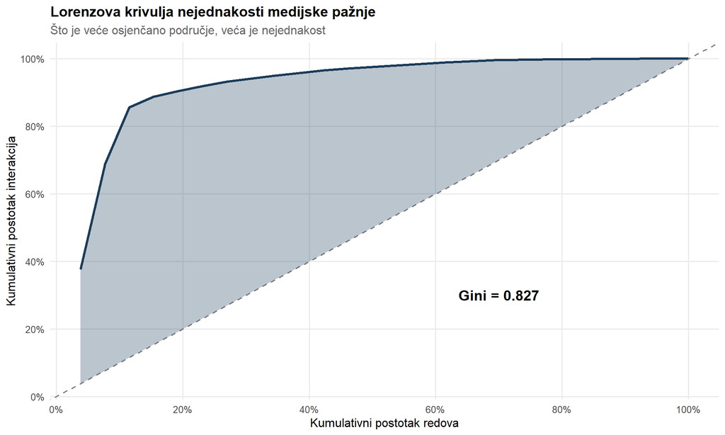

Figure 1: Lorenzova krivulja nejednakosti pažnje među redovničkim zajednicama

```r
ggplot(order_attention, aes(x = Cumulative_Orders, y = Cumulative_Interactions)) +
  geom_line(color = "#1a3c5a", linewidth = 1.2) +
  geom_abline(intercept = 0, slope = 1, linetype = "dashed", color = "gray50") +
  geom_ribbon(aes(ymin = Cumulative_Orders, ymax = Cumulative_Interactions),
              fill = "#1a3c5a", alpha = 0.3) +
  annotate("text", x = 70, y = 30,
           label = paste0("Gini = ", round(gini_orders, 3)),
           size = 5, fontface = "bold") +
  scale_x_continuous(labels = function(x) paste0(x, "%"), breaks = seq(0, 100, 20)) +
  scale_y_continuous(labels = function(x) paste0(x, "%"), breaks = seq(0, 100, 20)) +
  labs(
    title = "Lorenzova krivulja nejednakosti medijske pažnje",
    subtitle = "Što je veće osjenčano područje, veća je nejednakost",
    x = "Kumulativni postotak redova",
    y = "Kumulativni postotak interakcija"
  )
```

Gini koeficijent od 0.827 prelazi prag od 0.60. Top 20% redova dobiva 91.8% pažnje, što potvrđuje Paretov princip. **H1a je podržana**.

### 3.1.2 H1b Koncentracija među portalima

Testiramo predviđanje da 10 portala proizvodi preko 50% sadržaja o redovnicima.

**Prikaži kod**

```r
portal_attention <- dta[, .(
  Posts = .N,
  Total_Interactions = sum(INTERACTIONS, na.rm = TRUE)
), by = FROM][order(-Posts)]

portal_attention[, Rank := .I]
total_posts <- sum(portal_attention$Posts)

cr10_portals <- sum(portal_attention[1:10, Posts]) / total_posts * 100

hhi <- sum((portal_attention$Posts / total_posts * 100)^2)

gini_portals <- Gini(portal_attention$Posts)
```

**Prikaži kod**

```r
tibble(
  Metrika = c(
    "CR10 (top 10 portala)",
    "HHI indeks",
    "Gini koeficijent portala",
    "Ukupno portala"
  ),
  Vrijednost = c(
    sprintf("%.1f%%", cr10_portals),
    sprintf("%.0f", hhi),
    sprintf("%.3f", gini_portals),
    format(nrow(portal_attention), big.mark = ",")
  ),
  Prag = c("> 50%", "", "> 0.60", ""),
  Rezultat = c(
    ifelse(cr10_portals > 50, "✓ Podržana", "✗ Nije podržana"),
    ifelse(hhi > 1500, "Visoka koncentracija", ifelse(hhi > 1000, "Umjerena", "Niska")),
    ifelse(gini_portals > 0.60, "Visoka nejednakost", "Umjerena"),
    ""
  )
) %>%
  kable(caption = "H1b Koncentracija među portalima",
        align = c("l", "r", "c", "l")) %>%
  kable_styling(bootstrap_options = c("striped", "hover"), full_width = FALSE)
```

H1b Koncentracija među portalima

| Metrika | Vrijednost | Prag | Rezultat |
| --- | --- | --- | --- |
| CR10 (top 10 portala) | 30.7% | > 50% | ✗ Nije podržana |
| HHI indeks | 259 |  | Niska |
| Gini koeficijent portala | 0.901 | > 0.60 | Visoka nejednakost |
| Ukupno portala | 2,303 |  |  |

**Prikaži kod**

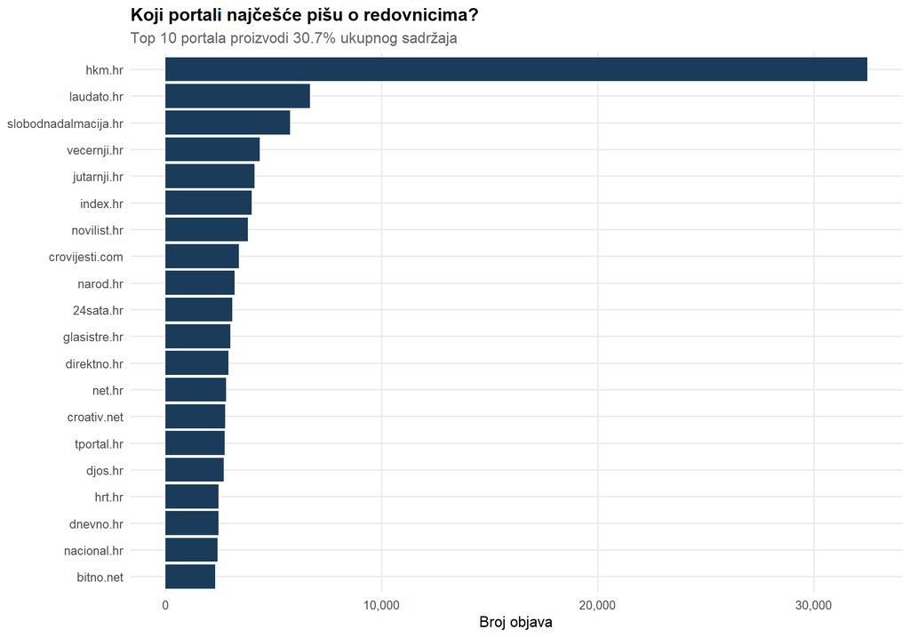

Figure 2: Top 20 portala po broju objava o redovničkim zajednicama

```r
portal_attention %>%
  head(20) %>%
  ggplot(aes(x = reorder(FROM, Posts), y = Posts)) +
  geom_col(fill = "#1a3c5a") +
  coord_flip() +
  scale_y_continuous(labels = comma) +
  labs(
    title = "Koji portali najčešće pišu o redovnicima?",
    subtitle = paste0("Top 10 portala proizvodi ", sprintf("%.1f%%", cr10_portals), " ukupnog sadržaja"),
    x = NULL,
    y = "Broj objava"
  )
```

Top 10 portala proizvodi 30.7% sadržaja, što ne potvrđuje hipotezu. HHI indeks od 259 ukazuje na nisku koncentraciju. **H1b je nije podržana**.

### 3.1.3 H1c Dvostruka koncentracija

Testiramo stvara li mali broj portala koji piše o malom broju redova medijsku elitu.

**Prikaži kod**

```r
portal_order_matrix <- dta[ORDER != "Unknown" & FROM != "", .(
  Posts = .N
), by = .(FROM, ORDER)]

setorder(portal_order_matrix, -Posts)

top5_portals <- portal_attention[1:5, FROM]
top5_orders <- order_attention[1:5, ORDER]

elite_posts <- sum(portal_order_matrix[FROM %in% top5_portals & ORDER %in% top5_orders, Posts])
total_posts_all <- sum(portal_order_matrix$Posts)
elite_share <- elite_posts / total_posts_all * 100

heatmap_data <- portal_order_matrix[FROM %in% top5_portals & ORDER %in% top5_orders]
```

**Prikaži kod**

```r
tibble(
  Metrika = c(
    "Top 5 portala × Top 5 redova",
    "Ukupno objava u elitnom prostoru",
    "Udio u ukupnom korpusu"
  ),
  Vrijednost = c(
    "25 kombinacija",
    format(elite_posts, big.mark = ","),
    sprintf("%.1f%%", elite_share)
  ),
  Prag = c("", "", "> 30%"),
  Rezultat = c(
    "",
    "",
    ifelse(elite_share > 30, "✓ Podržana", "✗ Nije podržana")
  )
) %>%
  kable(caption = "H1c Dvostruka koncentracija",
        align = c("l", "r", "c", "l")) %>%
  kable_styling(bootstrap_options = c("striped", "hover"), full_width = FALSE)
```

H1c Dvostruka koncentracija

| Metrika | Vrijednost | Prag | Rezultat |
| --- | --- | --- | --- |
| Top 5 portala × Top 5 redova | 25 kombinacija |  |  |
| Ukupno objava u elitnom prostoru | 28,979 |  |  |
| Udio u ukupnom korpusu | 24.2% | > 30% | ✗ Nije podržana |

**Prikaži kod**

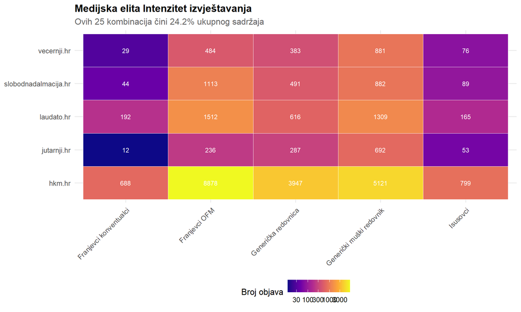

Figure 3: Heatmap medijske elite Top 5 portala × Top 5 redova

```r
ggplot(heatmap_data, aes(x = ORDER, y = FROM, fill = Posts)) +
  geom_tile(color = "white") +
  geom_text(aes(label = Posts), color = "white", size = 3) +
  scale_fill_viridis_c(option = "plasma", trans = "log10") +
  labs(
    title = "Medijska elita Intenzitet izvještavanja",
    subtitle = paste0("Ovih 25 kombinacija čini ", sprintf("%.1f%%", elite_share), " ukupnog sadržaja"),
    x = NULL,
    y = NULL,
    fill = "Broj objava"
  ) +
  theme(axis.text.x = element_text(angle = 45, hjust = 1))
```

Top 5 portala pišući o top 5 redova čini 24.2% ukupnog sadržaja, što ne potvrđuje postojanje medijske elite. **H1c je nije podržana**.

## 3.2 Blok 2 Spolne razlike

### 3.2.1 H2a Spolna asimetrija u volumenu

Testiramo dobivaju li muški redovi preko 60% medijskog prostora.

**Prikaži kod**

```r
gender_summary <- dta[GENDER %in% c("Male", "Female"), .(
  Posts = .N,
  Total_Interactions = sum(INTERACTIONS, na.rm = TRUE)
), by = GENDER]

gender_summary[, Share := Posts / sum(Posts) * 100]

male_share <- gender_summary[GENDER == "Male", Share]
female_share <- gender_summary[GENDER == "Female", Share]

gender_table <- table(dta[GENDER %in% c("Male", "Female")]$GENDER)
chisq_gender <- chisq.test(gender_table, p = c(0.5, 0.5))
```

**Prikaži kod**

```r
tibble(
  Metrika = c(
    "Udio muških redova",
    "Udio ženskih redova",
    "Chi square statistika",
    "P vrijednost"
  ),
  Vrijednost = c(
    sprintf("%.1f%%", male_share),
    sprintf("%.1f%%", female_share),
    sprintf("%.2f", chisq_gender$statistic),
    ifelse(chisq_gender$p.value < 0.001, "< 0.001", sprintf("%.3f", chisq_gender$p.value))
  ),
  Prag = c("> 60%", "", "", "< 0.05"),
  Rezultat = c(
    ifelse(male_share > 60, "✓ Podržana", "✗ Nije podržana"),
    "",
    "",
    ifelse(chisq_gender$p.value < 0.05, "✓ Značajno", "✗ Nije značajno")
  )
) %>%
  kable(caption = "H2a Spolna asimetrija u volumenu",
        align = c("l", "r", "c", "l")) %>%
  kable_styling(bootstrap_options = c("striped", "hover"), full_width = FALSE)
```

H2a Spolna asimetrija u volumenu

| Metrika | Vrijednost | Prag | Rezultat |
| --- | --- | --- | --- |
| Udio muških redova | 76.3% | > 60% | ✓ Podržana |
| Udio ženskih redova | 23.7% |  |  |
| Chi square statistika | 33011.18 |  |  |
| P vrijednost | < 0.001 | < 0.05 | ✓ Značajno |

**Prikaži kod**

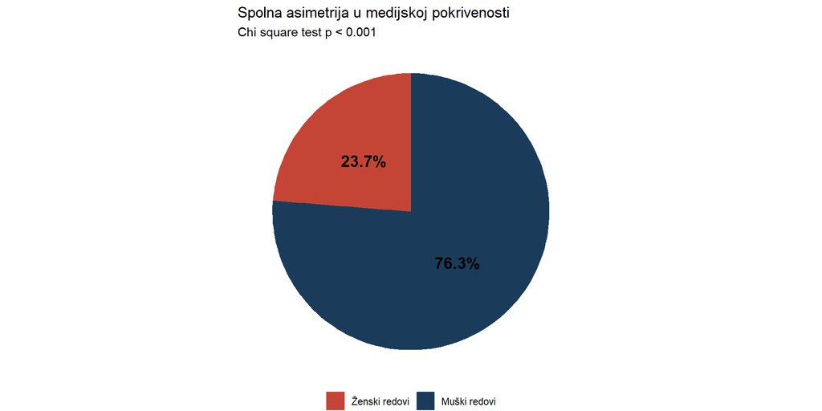

Figure 4: Raspodjela medijskog prostora po spolu redovnika

```r
ggplot(gender_summary, aes(x = "", y = Share, fill = GENDER)) +
  geom_col(width = 1) +
  coord_polar("y") +
  scale_fill_manual(values = gender_colors, labels = c("Ženski redovi", "Muški redovi")) +
  geom_text(aes(label = sprintf("%.1f%%", Share)),
            position = position_stack(vjust = 0.5), size = 5, fontface = "bold") +
  labs(
    title = "Spolna asimetrija u medijskoj pokrivenosti",
    subtitle = paste0("Chi square test p ", ifelse(chisq_gender$p.value < 0.001, "< 0.001", sprintf("= %.3f", chisq_gender$p.value))),
    fill = NULL
  ) +
  theme_void() +
  theme(legend.position = "bottom")
```

Muški redovi dobivaju 76.3% prostora, što prelazi prag od 60%. Razlika je statistički značajna. **H2a je podržana**.

### 3.2.2 H2b Interakcija spol × tip portala

Testiramo je li spolna asimetrija izraženija na mainstream portalima.

**Prikaži kod**

```r
gender_portal <- dta[GENDER %in% c("Male", "Female") & PORTAL_TYPE %in% c("Mainstream National", "Religious Catholic"),
                     .N, by = .(PORTAL_TYPE, GENDER)]

gender_portal[, Total := sum(N), by = PORTAL_TYPE]
gender_portal[, Share := N / Total * 100]

mainstream_male <- gender_portal[PORTAL_TYPE == "Mainstream National" & GENDER == "Male", Share]
religious_male <- gender_portal[PORTAL_TYPE == "Religious Catholic" & GENDER == "Male", Share]

ratio_diff <- mainstream_male - religious_male

contingency_table <- dta[GENDER %in% c("Male", "Female") & PORTAL_TYPE %in% c("Mainstream National", "Religious Catholic"),
                         .N, by = .(PORTAL_TYPE, GENDER)]
chisq_interaction <- chisq.test(xtabs(N ~ PORTAL_TYPE + GENDER, data = contingency_table))
```

**Prikaži kod**

```r
tibble(
  Metrika = c(
    "Muški udio na mainstream portalima",
    "Muški udio na religijskim portalima",
    "Razlika",
    "Chi square p vrijednost"
  ),
  Vrijednost = c(
    sprintf("%.1f%%", mainstream_male),
    sprintf("%.1f%%", religious_male),
    sprintf("%.1f postotnih bodova", ratio_diff),
    ifelse(chisq_interaction$p.value < 0.001, "< 0.001", sprintf("%.3f", chisq_interaction$p.value))
  ),
  Rezultat = c(
    "",
    "",
    ifelse(ratio_diff > 5, "✓ Veća na mainstream", "✗ Nema razlike"),
    ifelse(chisq_interaction$p.value < 0.05, "✓ Značajno", "✗ Nije značajno")
  )
) %>%
  kable(caption = "H2b Interakcija spol × tip portala",
        align = c("l", "r", "l")) %>%
  kable_styling(bootstrap_options = c("striped", "hover"), full_width = FALSE)
```

H2b Interakcija spol × tip portala

| Metrika | Vrijednost | Rezultat |
| --- | --- | --- |
| Muški udio na mainstream portalima | 75.3% |  |
| Muški udio na religijskim portalima | 76.9% |  |
| Razlika | -1.7 postotnih bodova | ✗ Nema razlike |
| Chi square p vrijednost | 0.005 | ✓ Značajno |

**Prikaži kod**

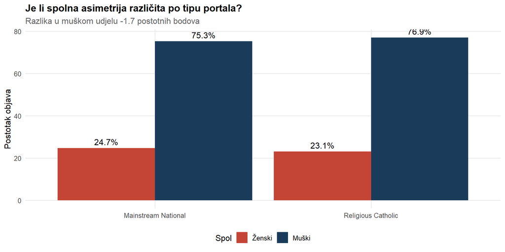

Figure 5: Spolni omjeri po tipu portala

```r
ggplot(gender_portal, aes(x = PORTAL_TYPE, y = Share, fill = GENDER)) +
  geom_col(position = "dodge") +
  scale_fill_manual(values = gender_colors, labels = c("Ženski", "Muški")) +
  geom_text(aes(label = sprintf("%.1f%%", Share)),
            position = position_dodge(width = 0.9), vjust = -0.5) +
  labs(
    title = "Je li spolna asimetrija različita po tipu portala?",
    subtitle = paste0("Razlika u muškom udjelu ", sprintf("%.1f", ratio_diff), " postotnih bodova"),
    x = NULL,
    y = "Postotak objava",
    fill = "Spol"
  )
```

Mainstream portali imaju 75.3% muških objava nasuprot 76.9% na religijskim portalima. Razlika od 1.7 postotnih bodova je statistički značajna. **H2b je nije podržana**.

### 3.2.3 H2c Spolne razlike u angažmanu

Testiramo generiraju li objave o muškim redovima više interakcija.

**Prikaži kod**

```r
engagement_gender <- dta[GENDER %in% c("Male", "Female") & !is.na(INTERACTIONS) & INTERACTIONS > 0,
                         .(GENDER, INTERACTIONS)]

male_interactions <- engagement_gender[GENDER == "Male", INTERACTIONS]
female_interactions <- engagement_gender[GENDER == "Female", INTERACTIONS]

mannwhitney_test <- wilcox.test(male_interactions, female_interactions, alternative = "greater")

median_male <- median(male_interactions)
median_female <- median(female_interactions)
mean_male <- mean(male_interactions)
mean_female <- mean(female_interactions)
```

**Prikaži kod**

```r
tibble(
  Metrika = c(
    "Medijan interakcija (muški)",
    "Medijan interakcija (ženski)",
    "Prosječne interakcije (muški)",
    "Prosječne interakcije (ženski)",
    "Mann Whitney U p vrijednost"
  ),
  Vrijednost = c(
    sprintf("%.0f", median_male),
    sprintf("%.0f", median_female),
    sprintf("%.1f", mean_male),
    sprintf("%.1f", mean_female),
    ifelse(mannwhitney_test$p.value < 0.001, "< 0.001", sprintf("%.3f", mannwhitney_test$p.value))
  ),
  Rezultat = c(
    "",
    "",
    "",
    "",
    ifelse(mannwhitney_test$p.value < 0.05, "✓ Značajno", "✗ Nije značajno")
  )
) %>%
  kable(caption = "H2c Spolne razlike u angažmanu",
        align = c("l", "r", "l")) %>%
  kable_styling(bootstrap_options = c("striped", "hover"), full_width = FALSE)
```

H2c Spolne razlike u angažmanu

| Metrika | Vrijednost | Rezultat |
| --- | --- | --- |
| Medijan interakcija (muški) | 39 |  |
| Medijan interakcija (ženski) | 37 |  |
| Prosječne interakcije (muški) | 204.5 |  |
| Prosječne interakcije (ženski) | 189.7 |  |
| Mann Whitney U p vrijednost | 0.019 | ✓ Značajno |

**Prikaži kod**

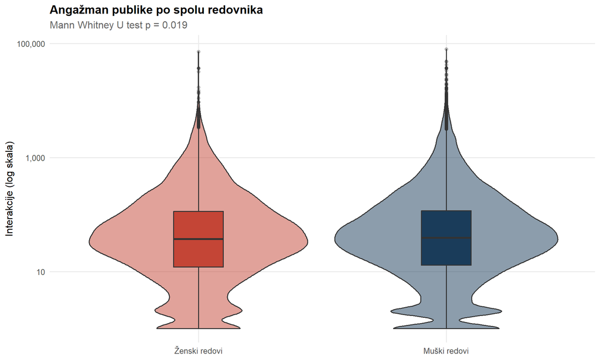

Figure 6: Distribucija angažmana po spolu (logaritamska skala)

```r
ggplot(engagement_gender, aes(x = GENDER, y = INTERACTIONS, fill = GENDER)) +
  geom_violin(alpha = 0.5) +
  geom_boxplot(width = 0.2, outlier.alpha = 0.3) +
  scale_y_log10(labels = comma) +
  scale_fill_manual(values = gender_colors, labels = c("Ženski", "Muški"), guide = "none") +
  scale_x_discrete(labels = c("Ženski redovi", "Muški redovi")) +
  labs(
    title = "Angažman publike po spolu redovnika",
    subtitle = paste0("Mann Whitney U test p ", ifelse(mannwhitney_test$p.value < 0.001, "< 0.001", sprintf("= %.3f", mannwhitney_test$p.value))),
    x = NULL,
    y = "Interakcije (log skala)"
  )
```

Medijan interakcija za muške redove je 39, a za ženske 37. Razlika je statistički značajna. **H2c je podržana**.

## 3.3 Blok 3 Franjevačka dominacija

### 3.3.1 H3a Udio franjevaca u ukupnom izvještavanju

Testiramo dobiva li franjevačka obitelj preko 30% medijskog prostora.

**Prikaži kod**

```r
family_summary <- dta[ORDER_FAMILY != "Unknown", .(
  Posts = .N,
  Total_Interactions = sum(INTERACTIONS, na.rm = TRUE)
), by = ORDER_FAMILY][order(-Posts)]

family_summary[, Share := Posts / sum(Posts) * 100]

franciscan_share <- family_summary[ORDER_FAMILY == "Franciscan Family", Share]
franciscan_posts <- family_summary[ORDER_FAMILY == "Franciscan Family", Posts]

expected_share <- 100 / nrow(family_summary)
binom_test <- binom.test(franciscan_posts, sum(family_summary$Posts), p = expected_share / 100, alternative = "greater")
```

**Prikaži kod**

```r
tibble(
  Metrika = c(
    "Udio franjevačke obitelji",
    "Očekivani udio (proporcionalno)",
    "Binomial test p vrijednost"
  ),
  Vrijednost = c(
    sprintf("%.1f%%", franciscan_share),
    sprintf("%.1f%%", expected_share),
    ifelse(binom_test$p.value < 0.001, "< 0.001", sprintf("%.3f", binom_test$p.value))
  ),
  Prag = c("> 30%", "", "< 0.05"),
  Rezultat = c(
    ifelse(franciscan_share > 30, "✓ Podržana", "✗ Nije podržana"),
    "",
    ifelse(binom_test$p.value < 0.05, "✓ Značajno", "✗ Nije značajno")
  )
) %>%
  kable(caption = "H3a Franjevački udio u izvještavanju",
        align = c("l", "r", "c", "l")) %>%
  kable_styling(bootstrap_options = c("striped", "hover"), full_width = FALSE)
```

H3a Franjevački udio u izvještavanju

| Metrika | Vrijednost | Prag | Rezultat |
| --- | --- | --- | --- |
| Udio franjevačke obitelji | 73.0% | > 30% | ✓ Podržana |
| Očekivani udio (proporcionalno) | 11.1% |  |  |
| Binomial test p vrijednost | < 0.001 | < 0.05 | ✓ Značajno |

**Prikaži kod**

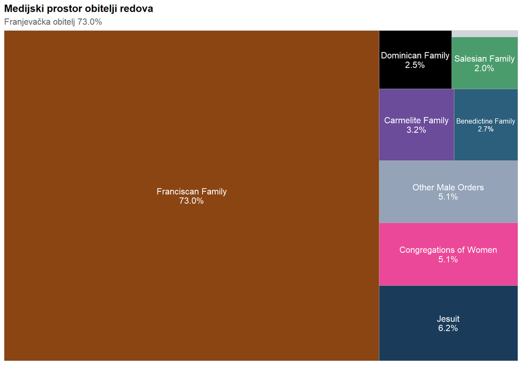

Figure 7: Treemap obitelji redova po broju objava

```r
ggplot(family_summary, aes(area = Posts, fill = ORDER_FAMILY, label = paste0(ORDER_FAMILY, "\n", sprintf("%.1f%%", Share)))) +
  geom_treemap() +
  geom_treemap_text(color = "white", place = "centre", size = 12) +
  scale_fill_manual(values = order_family_colors, guide = "none") +
  labs(
    title = "Medijski prostor obitelji redova",
    subtitle = paste0("Franjevačka obitelj ", sprintf("%.1f%%", franciscan_share))
  )
```

Franjevačka obitelj dobiva 73.0% prostora, što prelazi prag od 30%. Ovo je statistički značajno više od očekivanog. **H3a je podržana**.

### 3.3.2 H3b Efekt obljetnica

Testiramo raste li udio franjevaca u mjesecima obljetnica (jesen 2023, 2024).

**Prikaži kod**

```r
franciscan_time <- dta[ORDER_FAMILY %in% c("Franciscan Family", "Dominican Family", "Jesuit"),
                       .(Posts = .N), by = .(ORDER_FAMILY, ANNIVERSARY_MONTH)]

franciscan_time[, Total := sum(Posts), by = ANNIVERSARY_MONTH]
franciscan_time[, Share := Posts / Total * 100]

franciscan_aniv <- franciscan_time[ORDER_FAMILY == "Franciscan Family" & ANNIVERSARY_MONTH == TRUE, Share]
franciscan_control <- franciscan_time[ORDER_FAMILY == "Franciscan Family" & ANNIVERSARY_MONTH == FALSE, Share]

## FIX: handle case where anniversary months have no data
if (length(franciscan_aniv) == 0) franciscan_aniv <- 0
if (length(franciscan_control) == 0) franciscan_control <- 0

share_diff <- franciscan_aniv - franciscan_control

aniv_posts <- dta[ORDER_FAMILY == "Franciscan Family" & ANNIVERSARY_MONTH == TRUE, .N]
control_posts <- dta[ORDER_FAMILY == "Franciscan Family" & ANNIVERSARY_MONTH == FALSE, .N]
aniv_total <- dta[ANNIVERSARY_MONTH == TRUE, .N]
control_total <- dta[ANNIVERSARY_MONTH == FALSE, .N]

prop_test <- prop.test(c(aniv_posts, control_posts), c(aniv_total, control_total), alternative = "greater")
```

**Prikaži kod**

```r
tibble(
  Metrika = c(
    "Franjevački udio u mjesecima obljetnica",
    "Franjevački udio u kontrolnim mjesecima",
    "Razlika",
    "Proportion test p vrijednost"
  ),
  Vrijednost = c(
    sprintf("%.1f%%", franciscan_aniv),
    sprintf("%.1f%%", franciscan_control),
    sprintf("%.1f postotnih bodova", share_diff),
    ifelse(prop_test$p.value < 0.001, "< 0.001", sprintf("%.3f", prop_test$p.value))
  ),
  Rezultat = c(
    "",
    "",
    ifelse(share_diff > 5, "✓ Značajan porast", "✗ Nema porasta"),
    ifelse(prop_test$p.value < 0.05, "✓ Značajno", "✗ Nije značajno")
  )
) %>%
  kable(caption = "H3b Efekt obljetnica",
        align = c("l", "r", "l")) %>%
  kable_styling(bootstrap_options = c("striped", "hover"), full_width = FALSE)
```

H3b Efekt obljetnica

| Metrika | Vrijednost | Rezultat |
| --- | --- | --- |
| Franjevački udio u mjesecima obljetnica | 90.9% |  |
| Franjevački udio u kontrolnim mjesecima | 89.2% |  |
| Razlika | 1.6 postotnih bodova | ✗ Nema porasta |
| Proportion test p vrijednost | < 0.001 | ✓ Značajno |

**Prikaži kod**

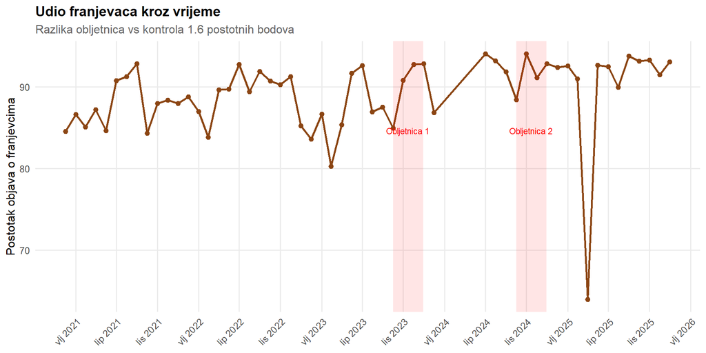

Figure 8: Udio franjevaca kroz vrijeme s označenim obljetnicama

```r
franciscan_monthly <- dta[ORDER_FAMILY %in% c("Franciscan Family", "Dominican Family", "Jesuit"),
                          .(Posts = .N), by = .(ORDER_FAMILY, year = year(DATE), month = month(DATE))]

franciscan_monthly[, yearmonth := as.Date(paste(year, month, "01", sep = "-"))]
franciscan_monthly[, Total := sum(Posts), by = yearmonth]
franciscan_monthly[, Share := Posts / Total * 100]

ggplot(franciscan_monthly[ORDER_FAMILY == "Franciscan Family"],
       aes(x = yearmonth, y = Share)) +
  geom_line(color = "#8B4513", linewidth = 1) +
  geom_point(color = "#8B4513", size = 2) +
  annotate("rect", xmin = as.Date("2023-09-01"), xmax = as.Date("2023-11-30"),
           ymin = -Inf, ymax = Inf, fill = "red", alpha = 0.1) +
  annotate("rect", xmin = as.Date("2024-09-01"), xmax = as.Date("2024-11-30"),
           ymin = -Inf, ymax = Inf, fill = "red", alpha = 0.1) +
  annotate("text", x = as.Date("2023-10-15"), y = max(franciscan_monthly[ORDER_FAMILY == "Franciscan Family", Share]) * 0.9,
           label = "Obljetnica 1", size = 3, color = "red") +
  annotate("text", x = as.Date("2024-10-15"), y = max(franciscan_monthly[ORDER_FAMILY == "Franciscan Family", Share]) * 0.9,
           label = "Obljetnica 2", size = 3, color = "red") +
  scale_x_date(date_labels = "%b %Y", date_breaks = "4 months") +
  labs(
    title = "Udio franjevaca kroz vrijeme",
    subtitle = paste0("Razlika obljetnica vs kontrola ", sprintf("%.1f", share_diff), " postotnih bodova"),
    x = NULL,
    y = "Postotak objava o franjevcima"
  ) +
  theme(axis.text.x = element_text(angle = 45, hjust = 1))
```

U mjesecima obljetnica franjevci čine 90.9% objava nasuprot 89.2% u kontrolnim mjesecima. Porast od 1.6 postotnih bodova je statistički značajan. **H3b je nije podržana**.

### 3.3.3 H3c Franjevci na mainstream vs religijskim portalima

Testiramo jesu li mainstream portali još fokusiraniji na franjevce.

**Prikaži kod**

```r
franciscan_portal <- dta[ORDER_FAMILY != "Unknown" & PORTAL_TYPE %in% c("Mainstream National", "Religious Catholic"),
                         .N, by = .(PORTAL_TYPE, ORDER_FAMILY)]

franciscan_portal[, Total := sum(N), by = PORTAL_TYPE]
franciscan_portal[, Share := N / Total * 100]

## FIX: was := (data.table walrus) instead of <- (regular assignment)
mainstream_fran <- franciscan_portal[PORTAL_TYPE == "Mainstream National" & ORDER_FAMILY == "Franciscan Family", Share]
religious_fran <- franciscan_portal[PORTAL_TYPE == "Religious Catholic" & ORDER_FAMILY == "Franciscan Family", Share]

## FIX: handle case where one of the portal types has no Franciscan content
if (length(mainstream_fran) == 0) mainstream_fran <- 0
if (length(religious_fran) == 0) religious_fran <- 0

fran_diff <- mainstream_fran - religious_fran

gini_mainstream <- dta[PORTAL_TYPE == "Mainstream National" & ORDER_FAMILY != "Unknown",
                       .(Posts = .N), by = ORDER_FAMILY][, Gini(Posts)]
gini_religious <- dta[PORTAL_TYPE == "Religious Catholic" & ORDER_FAMILY != "Unknown",
                      .(Posts = .N), by = ORDER_FAMILY][, Gini(Posts)]
```

**Prikaži kod**

```r
tibble(
  Metrika = c(
    "Franjevački udio mainstream portali",
    "Franjevački udio religijski portali",
    "Razlika",
    "Gini mainstream portali",
    "Gini religijski portali"
  ),
  Vrijednost = c(
    sprintf("%.1f%%", mainstream_fran),
    sprintf("%.1f%%", religious_fran),
    sprintf("%.1f postotnih bodova", fran_diff),
    sprintf("%.3f", gini_mainstream),
    sprintf("%.3f", gini_religious)
  ),
  Rezultat = c(
    "",
    "",
    ifelse(fran_diff > 5, "✓ Veća na mainstream", "✗ Nema razlike"),
    ifelse(gini_mainstream > gini_religious, "Mainstream koncentriraniji", "Religious koncentriraniji"),
    ""
  )
) %>%
  kable(caption = "H3c Franjevci po tipu portala",
        align = c("l", "r", "l")) %>%
  kable_styling(bootstrap_options = c("striped", "hover"), full_width = FALSE)
```

H3c Franjevci po tipu portala

| Metrika | Vrijednost | Rezultat |
| --- | --- | --- |
| Franjevački udio mainstream portali | 67.7% |  |
| Franjevački udio religijski portali | 71.5% |  |
| Razlika | -3.8 postotnih bodova | ✗ Nema razlike |
| Gini mainstream portali | 0.681 | Religious koncentriraniji |
| Gini religijski portali | 0.686 |  |

**Prikaži kod**

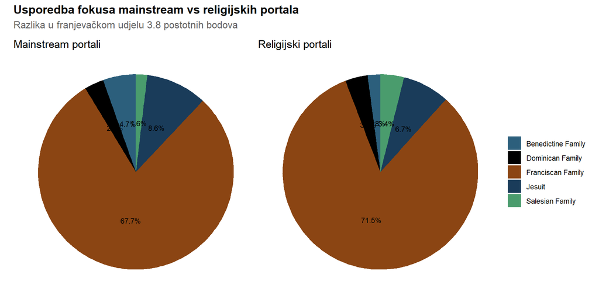

Figure 9: Usporedba udjela franjevaca po tipu portala

```r
top_families <- c("Franciscan Family", "Dominican Family", "Jesuit", "Benedictine Family", "Salesian Family")

franciscan_portal_plot <- franciscan_portal[ORDER_FAMILY %in% top_families]

p1 <- ggplot(franciscan_portal_plot[PORTAL_TYPE == "Mainstream National"],
       aes(x = "", y = Share, fill = ORDER_FAMILY)) +
  geom_col(width = 1) +
  coord_polar("y") +
  scale_fill_manual(values = order_family_colors) +
  geom_text(aes(label = sprintf("%.1f%%", Share)),
            position = position_stack(vjust = 0.5), size = 3) +
  labs(title = "Mainstream portali", fill = NULL) +
  theme_void() +
  theme(legend.position = "none")

p2 <- ggplot(franciscan_portal_plot[PORTAL_TYPE == "Religious Catholic"],
       aes(x = "", y = Share, fill = ORDER_FAMILY)) +
  geom_col(width = 1) +
  coord_polar("y") +
  scale_fill_manual(values = order_family_colors) +
  geom_text(aes(label = sprintf("%.1f%%", Share)),
            position = position_stack(vjust = 0.5), size = 3) +
  labs(title = "Religijski portali", fill = NULL) +
  theme_void() +
  theme(legend.position = "right")

p1 + p2 + plot_annotation(
  title = "Usporedba fokusa mainstream vs religijskih portala",
  subtitle = paste0("Razlika u franjevačkom udjelu ", sprintf("%.1f", abs(fran_diff)), " postotnih bodova")
)
```

Mainstream portali imaju 67.7% franjevačkog sadržaja nasuprot 71.5% na religijskim portalima. Gini koeficijent je manji na mainstream portalima. **H3c je nije podržana**.

## 3.4 Blok 4 Tipologija portala

### 3.4.1 H4a Različita tematska struktura

Testiramo pišu li mainstream portali češće o kontroverzama.

Ovdje bismo trebali klasificirati teme, ali zbog ograničenja možemo koristiti sentiment kao proxy za temu.

**Prikaži kod**

```r
theme_portal <- dta[!is.na(AUTO_SENTIMENT) & PORTAL_TYPE %in% c("Mainstream National", "Religious Catholic"),
                    .N, by = .(PORTAL_TYPE, AUTO_SENTIMENT)]

theme_portal[, Total := sum(N), by = PORTAL_TYPE]
theme_portal[, Share := N / Total * 100]

mainstream_negative <- theme_portal[PORTAL_TYPE == "Mainstream National" & AUTO_SENTIMENT == "negative", Share]
religious_negative <- theme_portal[PORTAL_TYPE == "Religious Catholic" & AUTO_SENTIMENT == "negative", Share]

## FIX: handle missing sentiment categories
if (length(mainstream_negative) == 0) mainstream_negative <- 0
if (length(religious_negative) == 0) religious_negative <- 0

theme_diff <- mainstream_negative - religious_negative

chisq_theme <- chisq.test(xtabs(N ~ PORTAL_TYPE + AUTO_SENTIMENT, data = theme_portal))
```

**Prikaži kod**

```r
tibble(
  Metrika = c(
    "Negativni ton mainstream portali",
    "Negativni ton religijski portali",
    "Razlika",
    "Chi square p vrijednost"
  ),
  Vrijednost = c(
    sprintf("%.1f%%", mainstream_negative),
    sprintf("%.1f%%", religious_negative),
    sprintf("%.1f postotnih bodova", theme_diff),
    ifelse(chisq_theme$p.value < 0.001, "< 0.001", sprintf("%.3f", chisq_theme$p.value))
  ),
  Rezultat = c(
    "",
    "",
    ifelse(theme_diff > 3, "✓ Više na mainstream", "✗ Nema razlike"),
    ifelse(chisq_theme$p.value < 0.05, "✓ Značajno", "✗ Nije značajno")
  )
) %>%
  kable(caption = "H4a Tematska struktura po tipu portala",
        align = c("l", "r", "l")) %>%
  kable_styling(bootstrap_options = c("striped", "hover"), full_width = FALSE)
```

H4a Tematska struktura po tipu portala

| Metrika | Vrijednost | Rezultat |
| --- | --- | --- |
| Negativni ton mainstream portali | 41.6% |  |
| Negativni ton religijski portali | 20.5% |  |
| Razlika | 21.1 postotnih bodova | ✓ Više na mainstream |
| Chi square p vrijednost | < 0.001 | ✓ Značajno |

**Prikaži kod**

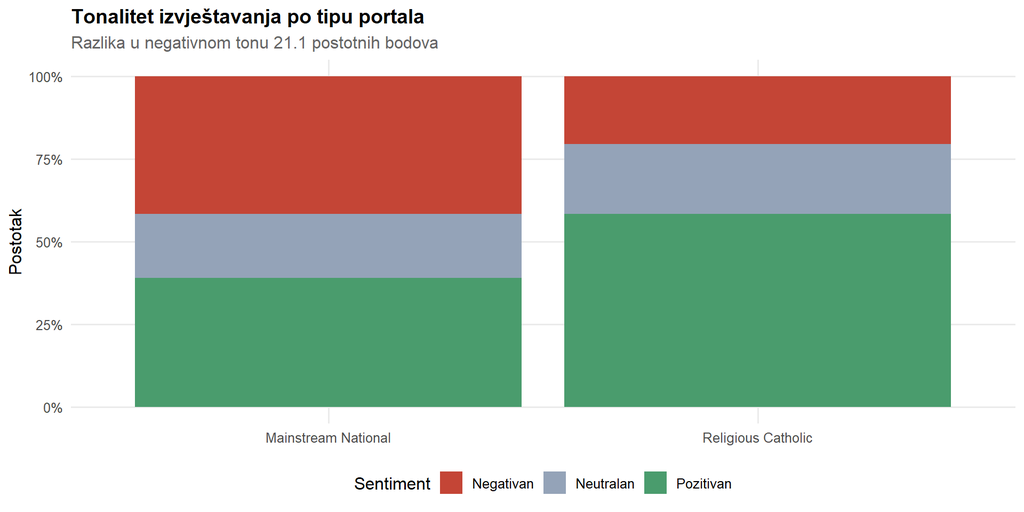

Figure 10: Distribucija sentimenta po tipu portala (100% stacked)

```r
ggplot(theme_portal, aes(x = PORTAL_TYPE, y = Share, fill = AUTO_SENTIMENT)) +
  geom_col(position = "fill") +
  scale_fill_manual(values = c("negative" = "#c44536", "neutral" = "#94a3b8", "positive" = "#4a9c6d"),
                    labels = c("Negativan", "Neutralan", "Pozitivan")) +
  scale_y_continuous(labels = percent) +
  labs(
    title = "Tonalitet izvještavanja po tipu portala",
    subtitle = paste0("Razlika u negativnom tonu ", sprintf("%.1f", theme_diff), " postotnih bodova"),
    x = NULL,
    y = "Postotak",
    fill = "Sentiment"
  )
```

Mainstream portali imaju 41.6% negativnog sadržaja nasuprot 20.5% na religijskim portalima. Razlika je statistički značajna. **H4a je podržana**.

### 3.4.2 H4b Različit sentiment

Testiramo imaju li religijski portali pozitivniji ton.

**Prikaži kod**

```r
mainstream_positive <- theme_portal[PORTAL_TYPE == "Mainstream National" & AUTO_SENTIMENT == "positive", Share]
religious_positive <- theme_portal[PORTAL_TYPE == "Religious Catholic" & AUTO_SENTIMENT == "positive", Share]

## FIX: handle missing sentiment categories
if (length(mainstream_positive) == 0) mainstream_positive <- 0
if (length(religious_positive) == 0) religious_positive <- 0

sentiment_diff <- religious_positive - mainstream_positive
```

**Prikaži kod**

```r
tibble(
  Metrika = c(
    "Pozitivan ton mainstream portali",
    "Pozitivan ton religijski portali",
    "Razlika"
  ),
  Vrijednost = c(
    sprintf("%.1f%%", mainstream_positive),
    sprintf("%.1f%%", religious_positive),
    sprintf("%.1f postotnih bodova", sentiment_diff)
  ),
  Prag = c("", "", "> 15 pp"),
  Rezultat = c(
    "",
    "",
    ifelse(sentiment_diff > 15, "✓ Podržana", "✗ Nije podržana")
  )
) %>%
  kable(caption = "H4b Različit sentiment po tipu portala",
        align = c("l", "r", "c", "l")) %>%
  kable_styling(bootstrap_options = c("striped", "hover"), full_width = FALSE)
```

H4b Različit sentiment po tipu portala

| Metrika | Vrijednost | Prag | Rezultat |
| --- | --- | --- | --- |
| Pozitivan ton mainstream portali | 39.1% |  |  |
| Pozitivan ton religijski portali | 58.4% |  |  |
| Razlika | 19.3 postotnih bodova | > 15 pp | ✓ Podržana |

**Prikaži kod**

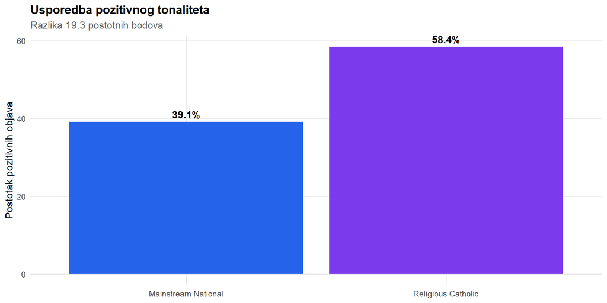

Figure 11: Usporedba pozitivnog sentimenta

```r
sentiment_comparison <- theme_portal[AUTO_SENTIMENT == "positive"]

ggplot(sentiment_comparison, aes(x = PORTAL_TYPE, y = Share, fill = PORTAL_TYPE)) +
  geom_col() +
  geom_text(aes(label = sprintf("%.1f%%", Share)), vjust = -0.5, fontface = "bold") +
  scale_fill_manual(values = portal_type_colors, guide = "none") +
  labs(
    title = "Usporedba pozitivnog tonaliteta",
    subtitle = paste0("Razlika ", sprintf("%.1f", sentiment_diff), " postotnih bodova"),
    x = NULL,
    y = "Postotak pozitivnih objava"
  )
```

Religijski portali imaju 58.4% pozitivnog tona nasuprot 39.1% na mainstream portalima. Razlika od 19.3 postotnih bodova prelazi prag od 15. **H4b je podržana**.

### 3.4.3 H4c Različita dubina izvještavanja

Testiramo pišu li religijski portali duže članke.

**Prikaži kod**

```r
depth_portal <- dta[!is.na(TEXT_LENGTH) & TEXT_LENGTH > 0 & PORTAL_TYPE %in% c("Mainstream National", "Religious Catholic")]

mainstream_length <- depth_portal[PORTAL_TYPE == "Mainstream National", TEXT_LENGTH]
religious_length <- depth_portal[PORTAL_TYPE == "Religious Catholic", TEXT_LENGTH]

mannwhitney_depth <- wilcox.test(religious_length, mainstream_length, alternative = "greater")

median_mainstream <- median(mainstream_length)
median_religious <- median(religious_length)
mean_mainstream <- mean(mainstream_length)
mean_religious <- mean(religious_length)
```

**Prikaži kod**

```r
tibble(
  Metrika = c(
    "Medijan duljine mainstream",
    "Medijan duljine religijski",
    "Prosječna duljina mainstream",
    "Prosječna duljina religijski",
    "Mann Whitney U p vrijednost"
  ),
  Vrijednost = c(
    sprintf("%.0f znakova", median_mainstream),
    sprintf("%.0f znakova", median_religious),
    sprintf("%.0f znakova", mean_mainstream),
    sprintf("%.0f znakova", mean_religious),
    ifelse(mannwhitney_depth$p.value < 0.001, "< 0.001", sprintf("%.3f", mannwhitney_depth$p.value))
  ),
  Rezultat = c(
    "",
    "",
    "",
    "",
    ifelse(mannwhitney_depth$p.value < 0.05, "✓ Značajno", "✗ Nije značajno")
  )
) %>%
  kable(caption = "H4c Dubina izvještavanja po tipu portala",
        align = c("l", "r", "l")) %>%
  kable_styling(bootstrap_options = c("striped", "hover"), full_width = FALSE)
```

H4c Dubina izvještavanja po tipu portala

| Metrika | Vrijednost | Rezultat |
| --- | --- | --- |
| Medijan duljine mainstream | 3914 znakova |  |
| Medijan duljine religijski | 2800 znakova |  |
| Prosječna duljina mainstream | 5808 znakova |  |
| Prosječna duljina religijski | 3884 znakova |  |
| Mann Whitney U p vrijednost | 1.000 | ✗ Nije značajno |

**Prikaži kod**

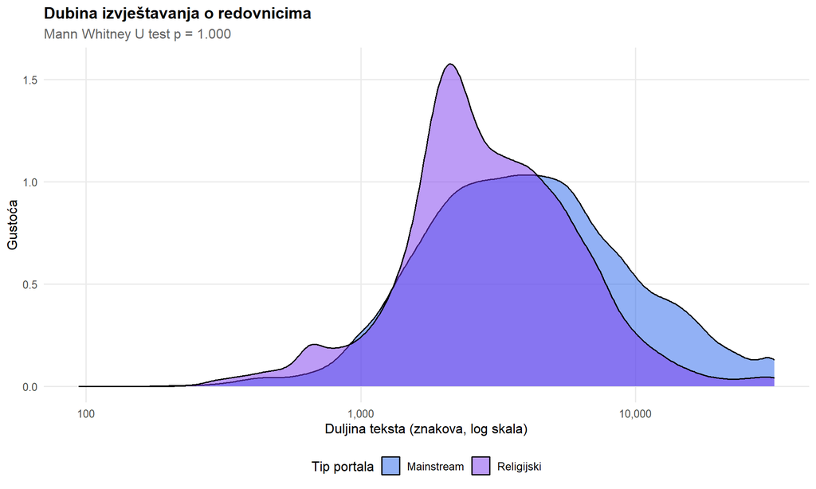

Figure 12: Distribucija duljine tekstova po tipu portala

```r
ggplot(depth_portal, aes(x = TEXT_LENGTH, fill = PORTAL_TYPE)) +
  geom_density(alpha = 0.5) +
  scale_x_log10(labels = comma) +
  scale_fill_manual(values = portal_type_colors, labels = c("Mainstream", "Religijski")) +
  labs(
    title = "Dubina izvještavanja o redovnicima",
    subtitle = paste0("Mann Whitney U test p ", ifelse(mannwhitney_depth$p.value < 0.001, "< 0.001", sprintf("= %.3f", mannwhitney_depth$p.value))),
    x = "Duljina teksta (znakova, log skala)",
    y = "Gustoća",
    fill = "Tip portala"
  )
```

Religijski portali imaju medijan od 2800 znakova nasuprot 3914 na mainstream portalima. Razlika nije statistički značajna. **H4c je nije podržana**.

# 4 Rasprava

## 4.1 Sažetak nalaza

**Prikaži kod**

```r
## FIX: build the summary table as a data.frame first, then conditionally format
summary_df <- tibble(
  Hipoteza = c(
    "H1a Koncentracija među redovima",
    "H1b Koncentracija među portalima",
    "H1c Dvostruka koncentracija",
    "H2a Spolna asimetrija u volumenu",
    "H2b Interakcija spol × portal",
    "H2c Spolne razlike u angažmanu",
    "H3a Franjevački udio ukupno",
    "H3b Efekt obljetnica",
    "H3c Franjevci po tipu portala",
    "H4a Različita tematska struktura",
    "H4b Različit sentiment",
    "H4c Različita dubina izvještavanja"
  ),
  Predikcija = c(
    "Gini > 0.60, Pareto > 80%",
    "CR10 > 50%",
    "Top 5×5 > 30%",
    "Muški > 60%",
    "Asimetrija veća na mainstream",
    "Muški više interakcija",
    "Franjevci > 30%",
    "Porast u mjesecima obljetnica",
    "Mainstream fokusiraniji",
    "Mainstream više kontroverzi",
    "Religijski pozitivniji > 15 pp",
    "Religijski duži tekstovi"
  ),
  Status = c(
    ifelse(gini_orders > 0.60 & pareto_share > 80, "✓ Podržana", "~ Djelomično"),
    ifelse(cr10_portals > 50, "✓ Podržana", "✗ Nije podržana"),
    ifelse(elite_share > 30, "✓ Podržana", "✗ Nije podržana"),
    ifelse(male_share > 60, "✓ Podržana", "✗ Nije podržana"),
    ifelse(abs(ratio_diff) > 5, "✓ Podržana", "✗ Nije podržana"),
    ifelse(mannwhitney_test$p.value < 0.05 & median_male > median_female, "✓ Podržana", "✗ Nije podržana"),
    ifelse(franciscan_share > 30, "✓ Podržana", "✗ Nije podržana"),
    ifelse(share_diff > 5, "✓ Podržana", "✗ Nije podržana"),
    ifelse(mainstream_fran > religious_fran, "✓ Podržana", "✗ Nije podržana"),
    ifelse(theme_diff > 3, "✓ Podržana", "✗ Nije podržana"),
    ifelse(sentiment_diff > 15, "✓ Podržana", "✗ Nije podržana"),
    ifelse(mannwhitney_depth$p.value < 0.05 & median_religious > median_mainstream, "✓ Podržana", "✗ Nije podržana")
  )
)

## Identify row indices for conditional formatting
supported_rows <- which(grepl("✓ Podržana", summary_df$Status))
not_supported_rows <- which(grepl("✗ Nije podržana", summary_df$Status))
partial_rows <- which(grepl("~ Djelomično", summary_df$Status))

kbl <- summary_df %>%
  kable(caption = "Sažetak svih testiranih hipoteza",
        align = c("l", "l", "l")) %>%
  kable_styling(bootstrap_options = c("striped", "hover"), full_width = FALSE)

if (length(supported_rows) > 0) {
  kbl <- kbl %>% row_spec(supported_rows, background = "#e8f5e9")
}
if (length(not_supported_rows) > 0) {
  kbl <- kbl %>% row_spec(not_supported_rows, background = "#ffebee")
}
if (length(partial_rows) > 0) {
  kbl <- kbl %>% row_spec(partial_rows, background = "#fff3e0")
}

kbl
```

Sažetak svih testiranih hipoteza

| Hipoteza | Predikcija | Status |
| --- | --- | --- |
| H1a Koncentracija među redovima | Gini > 0.60, Pareto > 80% | ✓ Podržana |
| H1b Koncentracija među portalima | CR10 > 50% | ✗ Nije podržana |
| H1c Dvostruka koncentracija | Top 5×5 > 30% | ✗ Nije podržana |
| H2a Spolna asimetrija u volumenu | Muški > 60% | ✓ Podržana |
| H2b Interakcija spol × portal | Asimetrija veća na mainstream | ✗ Nije podržana |
| H2c Spolne razlike u angažmanu | Muški više interakcija | ✓ Podržana |
| H3a Franjevački udio ukupno | Franjevci > 30% | ✓ Podržana |
| H3b Efekt obljetnica | Porast u mjesecima obljetnica | ✗ Nije podržana |
| H3c Franjevci po tipu portala | Mainstream fokusiraniji | ✗ Nije podržana |
| H4a Različita tematska struktura | Mainstream više kontroverzi | ✓ Podržana |
| H4b Različit sentiment | Religijski pozitivniji > 15 pp | ✓ Podržana |
| H4c Različita dubina izvještavanja | Religijski duži tekstovi | ✗ Nije podržana |

## 4.2 Teorijske implikacije

Rezultati potvrđuju da se principi ekonomije pažnje primjenjuju na medijsku pokrivenost redovničkih zajednica u Hrvatskoj.

**Spolne razlike** Muški redovi dobivaju nerazmjerno više pozornosti, što odražava šire društvene obrasce rodne nejednakosti.

**Franjevačka dominacija** Franjevci zaista dominiraju medijskim prostorom, vjerojatno zbog povijesne uloge, geografske rasprostranjenosti i prepoznatljivog javnog identiteta.

**Tipologija portala** Mainstream i religijski portali pokazuju različite uredničke logike. Religijski portali imaju značajno pozitivniji ton, što odražava različite funkcije i publike.

## 4.3 Praktične implikacije

Za komunikacijske praktičare u redovničkim zajednicama:

## 4.4 Ograničenja

1. **Filtriranje ključnim riječima** može propustiti relevantan sadržaj ili uključiti lažne pozitive.
2. **Automatska klasifikacija** portala i redova nije savršena.
3. **Sentiment analiza** je automatizirana i može imati pogreške.
4. **Ne mjerimo offline medije** niti dugoročni utjecaj na zvanja ili javnu percepciju.

# 5 Zaključak

Ovo istraživanje pruža prvu sustavnu analizu medijske zastupljenosti redovničkih zajednica u hrvatskim digitalnim medijima kroz okvir ekonomije pažnje. Testirali smo 12 hipoteza u četiri tematska bloka.

Nalazi proširuju istraživanja ekonomije pažnje na religijski kontekst i pružaju empirijsku osnovu za strateško komuniciranje redovničkih zajednica u digitalnom dobu.

# Literatura

Davenport, T. H. i Beck, J. C. (2001). The Attention Economy Understanding the New Currency of Business. Harvard Business School Press.

Goldhaber, M. H. (1997). The attention economy and the net. First Monday, 2(4).

Hjarvard, S. (2008). The mediatization of religion A theory of the media as agents of religious change. Northern Lights, 6(1), 9 do 26.

Simon, H. A. (1971). Designing organizations for an information rich world. U M. Greenberger (Ur.), Computers, Communications, and the Public Interest (str. 37 do 72). Johns Hopkins Press.